# Seasonal GAM Data Exploration

Ryan Hankins

# Models

Spring Model

Model 1: Spring Chla ~ s(logNH4) + s(logPO4) + s(log(NO2+NO3)) + s(temperature) + s(logconductivity) + Sac Valley index + previous year(Sac Valley index) + s(Region:logSAC) + s(Region:logSJ)+ s(Region:logExports) + Pre/post-clam + s(Region:lag(logSAC)) + s(Region:lag(logSJ)) + lag(logNH4) + s(lag(PO4)) + s(lag(logNO2+NO3)) + (1|Month)

Model 2: Spring Chla ~ s(logNH4) + s(logPO4) + s(log(NO2+NO3)) + s(temperature) + s(logconductivity) + Sac Valley index + previous year(Sac Valley index) + Pre/post-clam + s(lag(logNDOI)) + s(Region:log(NDOI)) + lag(logNH4) + s(lag(PO4)) + s(lag(logNO2+NO3)) + (1|Month)

Summer Model

Model 1: Summer Chla ~ s(logNH4) + s(logPO4) + s(log(NO2+NO3)) + s(temperature) + s(logconductivity) + Sac Valley index + previous year(Sac Valley index) + s(Region:logSAC) + s(Region:logSJ)+ s(Region:logExports) + Pre/post-clam + s(Region:lag(logSAC)) + s(Region:lag(logSJ)) + lag(logNH4) + s(lag(PO4)) + s(lag(logNO2+NO3)) + (1|Month)

Model 2: Summer Chla ~ s(logNH4) + s(logPO4) + s(log(NO2+NO3)) + s(temperature) + s(logconductivity) + Sac Valley index + previous year(Sac Valley index) + Pre/post-clam + s(lag(logNDOI)) + s(Region:log(NDOI)) + lag(logNH4) + s(lag(PO4)) + s(lag(logNO2+NO3)) + (1|Month)

# Prepare Data

```r
# variables to include in the analysis:

df <- read.csv("Data/regional_integrated_dataset3.csv" )

df$Date = as.Date(df$Date)

# 1979 is the start of the study period.
df <- subset(df,df$Date >= "1979-01-01")
# 2022 is the end of the study period
df <- subset(df,df$Date <= "2022-12-31")

# Changing categorical variables to factors
# need to change regions to factor farther down so dataframe splitting by region works properly
#df$Regions = as.factor(df$Regions)
df$season = as.factor(df$season)
df$season_num = as.numeric(df$season)

# log transforming chl-a to achieve normal distribution of response variable.
df$logchla <- log(df$Chlorophyll)

# log transforming some variables to better visualize
df$logDissNitrateNitrite <- log(df$DissNitrateNitrite)
df$logDissAmmonia <- log(df$DissAmmonia)
df$logDissOrthophos <- log(df$DissOrthophos)
df$logConductivity <- log(df$Conductivity)
df$logSAC <- log(df$SAC)
df$logOUT <- log(df$OUT)
df$logSJR <- log(df$SJR)

#Replacing clam variables with a step function (pre/post potamocorbula introduction to the Bay in 1987)
df <- df%>%mutate(clam_step=if_else(Year>1987, "post clam", "pre clam"))
df$clam_step <- as.factor(df$clam_step)
df$Chlorophyll <- as.numeric(df$Chlorophyll)
```

## add lag terms

```r
# Create monthly lag terms
df<- df %>% arrange(Year, Month) %>% mutate(across(c(DissAmmonia,logDissAmmonia,DissOrthophos,logDissOrthophos,DissNitrateNitrite,logDissNitrateNitrite,Temperature, Conductivity,logConductivity, SAC, logSAC, SJR, logSJR, EXPORT, OUT, logOUT, Index),
                                       ~ lag(.x, n = 1),
                                       .names = "lag{.col}_mo"))

# Create seasonal lag terms for the log terms
# This code is taken from clamdata_cleanup_AB_261125.R
#Step 1: summarize by season
wq_r_sum_lagseason <- df %>%
  group_by(Regions,Year,season) %>%
  summarize(across(where(is.numeric),\(x) mean(x, na.rm = TRUE)), .groups="drop_last")

#Step 2: Add a column for the following season.
#This seems counter-intuitive because the lag should be the prior season,
#but this is a merge column: it will merge back with the prior season
#in the original table.
wq_r_sum_lagseason <- wq_r_sum_lagseason %>%
  select(!c(lagOUT,lagSAC,lagTemperature,lagDissAmmonia,lagDissNitrateNitrite, lagTotPhos,lagConductivity,lagDissOrthophos))%>%
  rename_with(~paste0("lag",.x)) %>%
  rename(Year = "lagYear",season = "lagseason", Regions="lagRegions") %>%
  mutate(lagseason = case_when(
    season == "Spring" ~ "Summer",
    season == "Summer" ~ "Autumn",
    season == "Autumn" ~ "Winter",
    season == "Winter" ~ "Spring"
  )) %>%
  mutate(lagseasonyear = case_when(
    season == "Autumn" ~ Year+1,
    !(season == "Autumn") ~ Year
  )) %>%
  mutate(lagseasonyear = paste0(lagseason,lagseasonyear)) %>%
  ungroup %>%
  select(lagseasonyear, Regions, laglogDissAmmonia,laglogDissNitrateNitrite, laglogDissOrthophos, laglogConductivity,
         laglogSAC,laglogOUT, laglogSJR, laglogDissOrthophos, lagIndex, lagEXPORT)


df <- df %>%
  mutate(seasonyear = paste0(season,year(Date))) %>%
  merge(wq_r_sum_lagseason,by.x=c("Regions","seasonyear"),by.y=c("Regions","lagseasonyear"),all.x=T) %>%
  select(-seasonyear)%>%
  relocate(Date)
```

## make the final dataset

```r
c = c("logchla", "season", "Regions", "Date","Year", "Month","SAC","lagSAC", "lagSAC_mo", "logSAC", "laglogSAC","laglogSAC_mo", "EXPORT", "lagEXPORT", "lagEXPORT_mo", "OUT","lagOUT","lagOUT_mo", "logOUT", "laglogOUT", "laglogOUT_mo", "SJR", "lagSJR","lagSJR_mo","logSJR", "laglogSJR", "laglogSJR_mo", "Index","lagIndex_mo","DissAmmonia","lagDissAmmonia","lagDissAmmonia_mo","logDissAmmonia","laglogDissAmmonia","laglogDissAmmonia_mo","DissOrthophos","lagDissOrthophos","logDissOrthophos","laglogDissOrthophos","laglogDissOrthophos_mo","DissNitrateNitrite","lagDissNitrateNitrite","logDissNitrateNitrite","laglogDissNitrateNitrite","laglogDissNitrateNitrite_mo","Temperature","lagTemperature","lagTemperature_mo","Conductivity",  "lagConductivity","lagConductivity_mo","logConductivity","laglogConductivity_mo","clam_step")

df <- df %>% subset(select=c)

smr <- df %>% filter(season == "Summer")
smr_z <- smr %>% mutate(across(!c(Regions,season,Date,Month, Year, clam_step), ~as.vector(scale(.))))
spr <- df %>% filter(season == "Spring") %>% subset(select = c)
spr_z <- spr %>% mutate(across(!c(Regions,, season, Date,Month, Year,clam_step), ~as.vector(scale(.))))
```

# Summer

## correlation matrix

```r
smr_numeric = smr_z %>% select(where(is.numeric))
smr_numeric = smr_numeric %>% drop_na()
m = cor(smr_numeric)

m_df <- data.frame(m)
rmarkdown::paged_table(m_df)
```

|  | logchla | Year | Month | SAC | lagSAC | lagSAC_mo | logSAC | laglogSAC | laglogSAC_mo | EXPORT | lagEXPORT | lagEXPORT_mo | OUT | lagOUT | lagOUT_mo | logOUT | laglogOUT | laglogOUT_mo | SJR | lagSJR | lagSJR_mo | logSJR | laglogSJR | laglogSJR_mo | Index | lagIndex_mo | DissAmmonia | lagDissAmmonia | lagDissAmmonia_mo | … |
| --- | --- | --- | --- | --- | --- | --- | --- | --- | --- | --- | --- | --- | --- | --- | --- | --- | --- | --- | --- | --- | --- | --- | --- | --- | --- | --- | --- | --- | --- | --- |
| logchla | 1.000000000 | -0.010846261 | -0.1316978536 | 0.027213809 | -0.04301943 | 0.031317265 | 0.044534374 | -0.01936285 | 0.0411313399 | 0.063485830 | 0.032643133 | 0.04149228 | -0.03843570 | -0.044108026 | -0.008795062 | -0.006410483 | -0.02509610 | 0.006389821 | -0.036762923 | -0.039860898 | -0.01585082 | -0.01592196 | -0.0216002520 | -0.006486416 | -0.024361193 | -0.024361193 | -0.1567767450 | -0.283227412 | 0.525941522 | … |
| Year | -0.010846261 | 1.000000000 | -0.0046564243 | -0.500752741 | -0.36123306 | -0.466771557 | -0.484555403 | -0.40881923 | -0.4779100573 | -0.273116667 | -0.392995982 | -0.27168797 | -0.46974219 | -0.334051030 | -0.413319686 | -0.436840574 | -0.38105093 | -0.419781552 | -0.462749268 | -0.374596701 | -0.42561384 | -0.56247142 | -0.4284232962 | -0.540776971 | -0.482628623 | -0.482628623 | -0.0938501030 | -0.030466806 | -0.095462525 | … |
| Month | -0.131697854 | -0.004656424 | 1.0000000000 | -0.209004814 | 0.01572476 | -0.182295923 | -0.184194072 | 0.02070050 | -0.1471985407 | -0.004776445 | -0.001135371 | 0.08700283 | -0.13842183 | 0.007054151 | -0.190617421 | -0.174182202 | 0.01890865 | -0.219626534 | -0.140425712 | -0.007428271 | -0.17370986 | -0.04233302 | -0.0002530298 | -0.083613041 | 0.008488340 | 0.008488340 | 0.0405343128 | -0.009070472 | 0.030688122 | … |
| SAC | 0.027213809 | -0.500752741 | -0.2090048136 | 1.000000000 | 0.75277606 | 0.902022232 | 0.978497177 | 0.82057571 | 0.9341412558 | 0.621296453 | 0.572117373 | 0.57415389 | 0.77393006 | 0.686373080 | 0.696672722 | 0.868735070 | 0.79931469 | 0.834596112 | 0.677769933 | 0.661238097 | 0.64509765 | 0.74428400 | 0.7660740306 | 0.740917266 | 0.792811313 | 0.792811313 | -0.0227415004 | -0.118107733 | -0.029844897 | … |
| lagSAC | -0.043019432 | -0.361233059 | 0.0157247612 | 0.752776064 | 1.00000000 | 0.726880942 | 0.707331331 | 0.96763926 | 0.7144581733 | 0.413201955 | 0.625530242 | 0.41785946 | 0.76343529 | 0.975256844 | 0.704901044 | 0.852736744 | 0.97452351 | 0.830330182 | 0.782905970 | 0.924814053 | 0.76100130 | 0.84421866 | 0.9193139894 | 0.840148921 | 0.919167381 | 0.919167381 | -0.0481194016 | -0.260945898 | -0.057676650 | … |
| lagSAC_mo | 0.031317265 | -0.466771557 | -0.1822959228 | 0.902022232 | 0.72688094 | 1.000000000 | 0.874604828 | 0.77978051 | 0.9579821271 | 0.550583753 | 0.526410259 | 0.53283303 | 0.75179041 | 0.666611449 | 0.828917476 | 0.811575943 | 0.76189250 | 0.860647710 | 0.701272998 | 0.643172231 | 0.73363678 | 0.72711773 | 0.7275212164 | 0.733048955 | 0.748933985 | 0.748933985 | -0.0347548538 | -0.123118837 | -0.054357123 | … |
| logSAC | 0.044534374 | -0.484555403 | -0.1841940722 | 0.978497177 | 0.70733133 | 0.874604828 | 1.000000000 | 0.81116087 | 0.9523672886 | 0.738295032 | 0.629881538 | 0.68738445 | 0.65442442 | 0.631574478 | 0.590112082 | 0.786991204 | 0.78329493 | 0.760153301 | 0.577410279 | 0.596518540 | 0.55154283 | 0.72215475 | 0.7578255319 | 0.719175983 | 0.768659155 | 0.768659155 | 0.0052463405 | -0.091430504 | -0.002890345 | … |
| laglogSAC | -0.019362847 | -0.408819227 | 0.0207005049 | 0.820575714 | 0.96763926 | 0.779780509 | 0.811160868 | 1.00000000 | 0.8112983019 | 0.594293022 | 0.735329769 | 0.58953399 | 0.69863783 | 0.908218479 | 0.646379745 | 0.827493867 | 0.98815095 | 0.808707239 | 0.720065405 | 0.844832413 | 0.69858137 | 0.86653248 | 0.9298935779 | 0.860238108 | 0.918269960 | 0.918269960 | -0.0184432521 | -0.228241888 | -0.029166607 | … |
| laglogSAC_mo | 0.041131340 | -0.477910057 | -0.1471985407 | 0.934141256 | 0.71445817 | 0.957982127 | 0.952367289 | 0.81129830 | 1.0000000000 | 0.713077250 | 0.621418174 | 0.70097583 | 0.65317129 | 0.639904465 | 0.676069678 | 0.765809127 | 0.78429762 | 0.792531497 | 0.606123266 | 0.603334848 | 0.61666717 | 0.73281684 | 0.7554225062 | 0.729251448 | 0.764601691 | 0.764601691 | 0.0009319686 | -0.098518301 | -0.019608334 | … |
| EXPORT | 0.063485830 | -0.273116667 | -0.0047764447 | 0.621296453 | 0.41320195 | 0.550583753 | 0.738295032 | 0.59429302 | 0.7130772499 | 1.000000000 | 0.707109538 | 0.94412114 | 0.06821718 | 0.318889252 | 0.087958083 | 0.279099710 | 0.55271961 | 0.296745897 | 0.137311967 | 0.234440380 | 0.14442445 | 0.51750689 | 0.5425268267 | 0.511730343 | 0.489792524 | 0.489792524 | 0.1135728636 | 0.017619749 | 0.103291784 | … |

[output cut: 40 more lines]

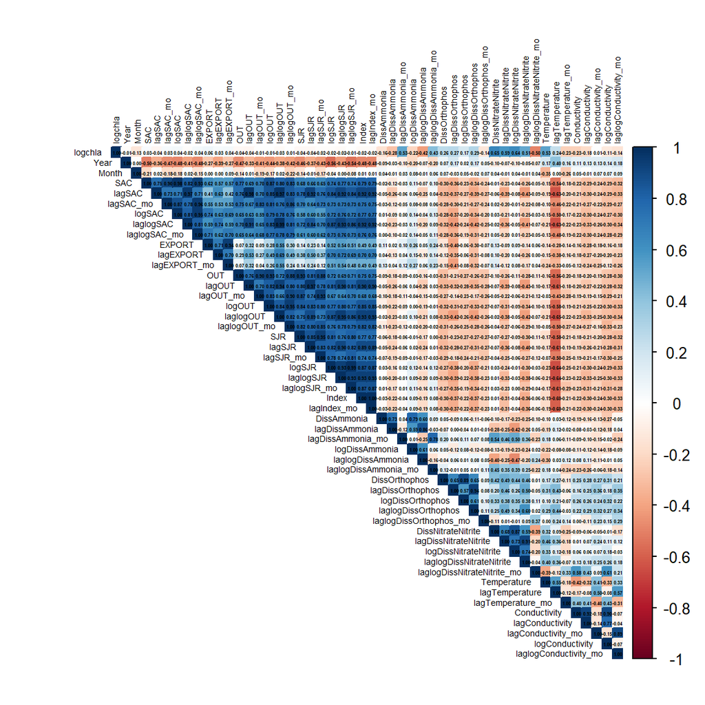

```r
corrplot(m,
         method = "color",
         type = "upper",
         addCoef.col = "black",
         number.cex = 0.25,
         number.digits=2,
         tl.cex =0.45,
         tl.col = "black")
```

## bivariate plots (z-scored)

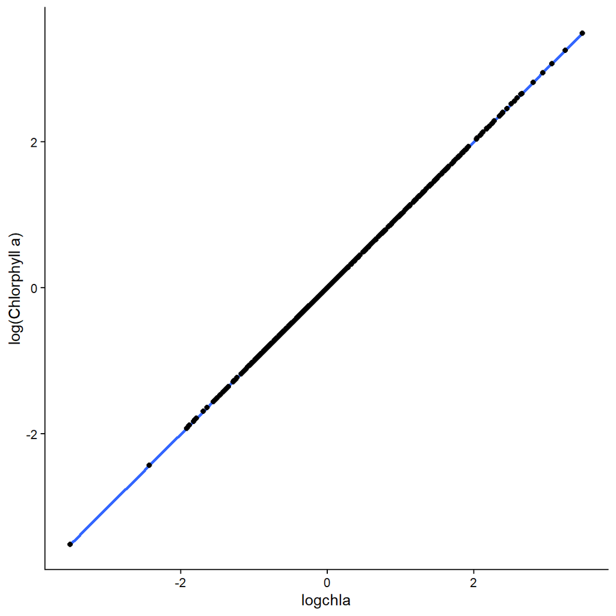

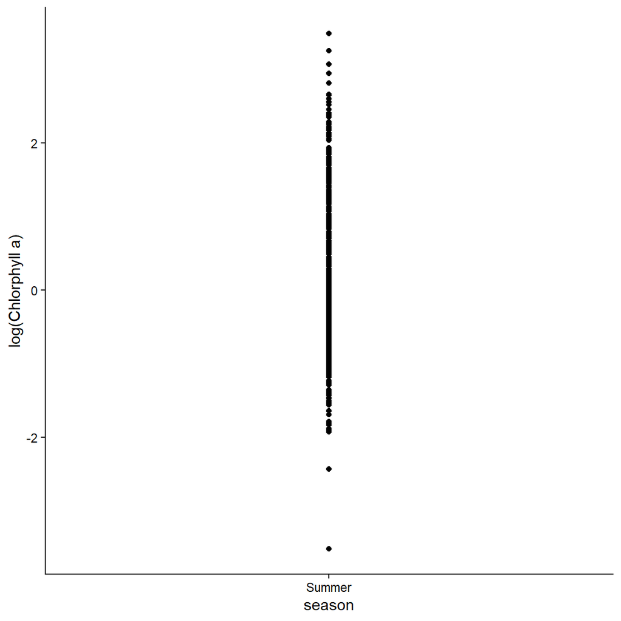

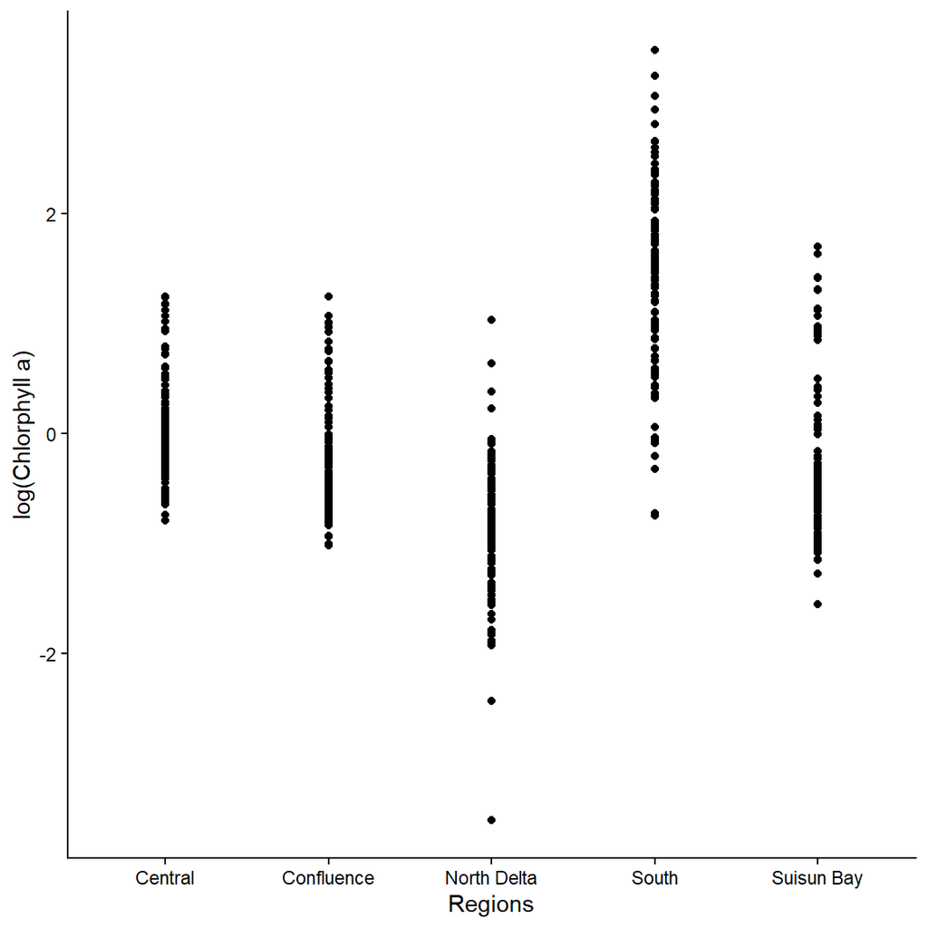

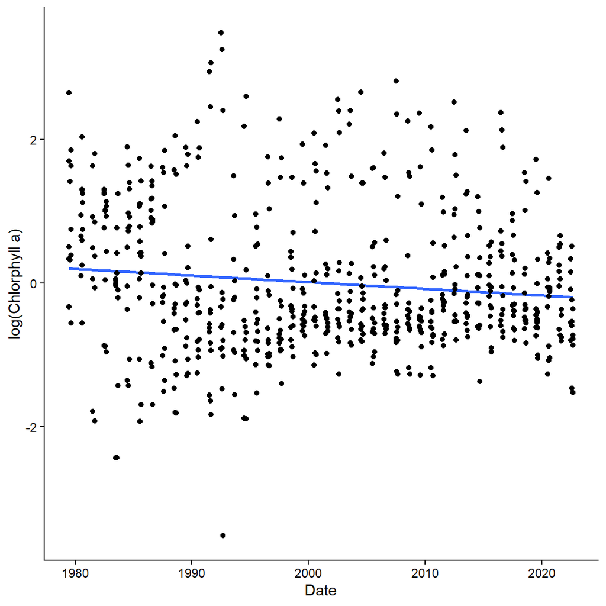

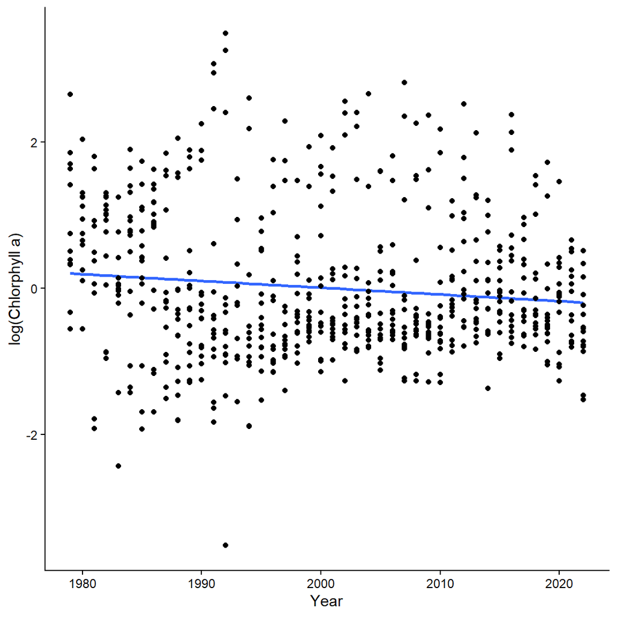

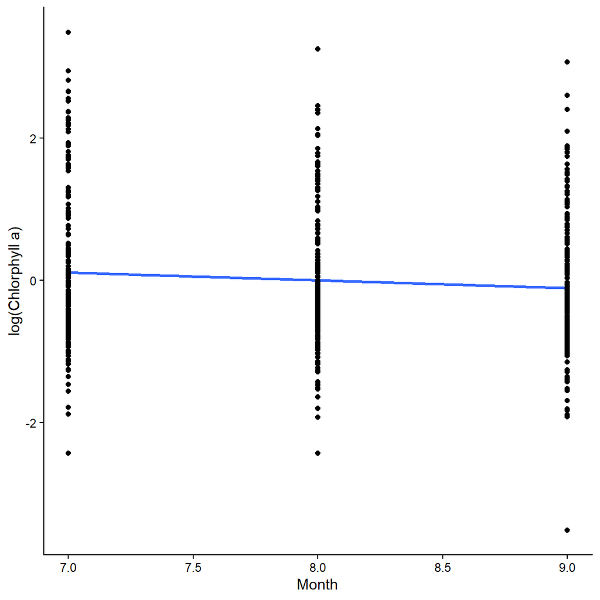

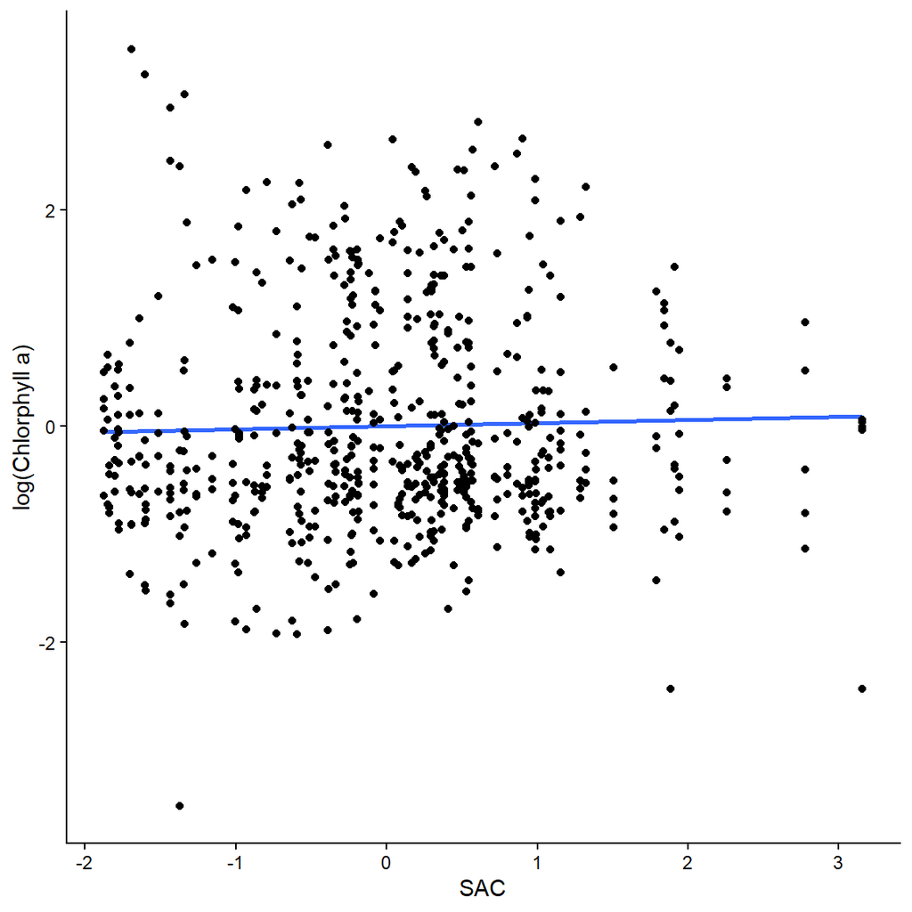

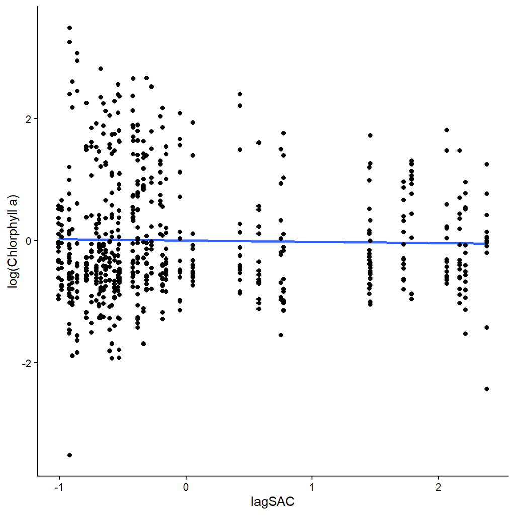

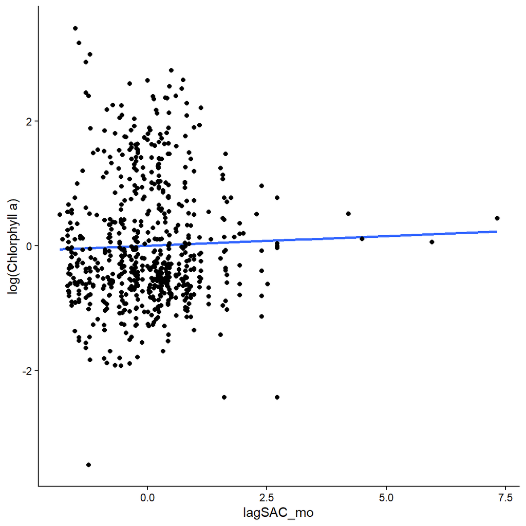

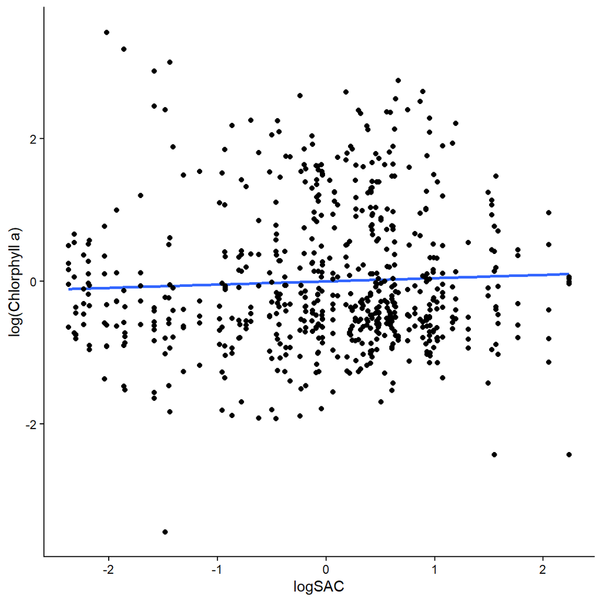

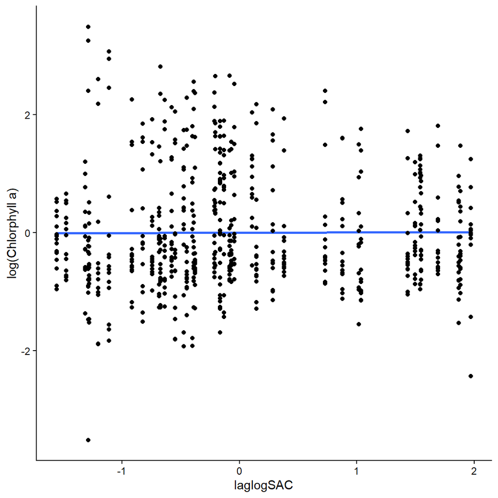

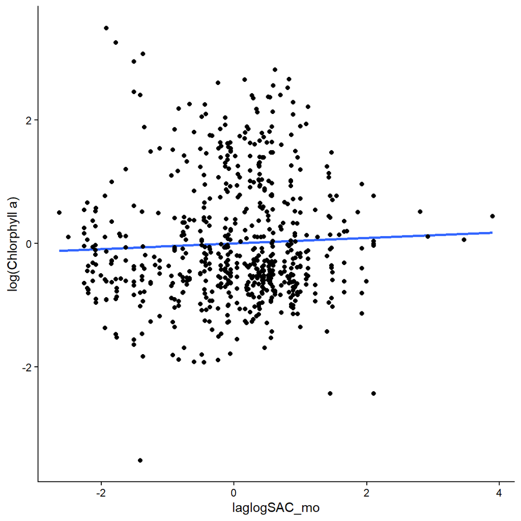

[42 more figures not shown]

```r
lapply(c, function(x) {
  ggplot(smr_z, mapping =aes(x = .data[[x]], y = logchla)) +
    ylab("log(Chlorphyll a)")+
    geom_smooth(method="lm", se=FALSE)+
    geom_point()+
    theme_classic()})
```

## bivariate plots by region (z-scored)

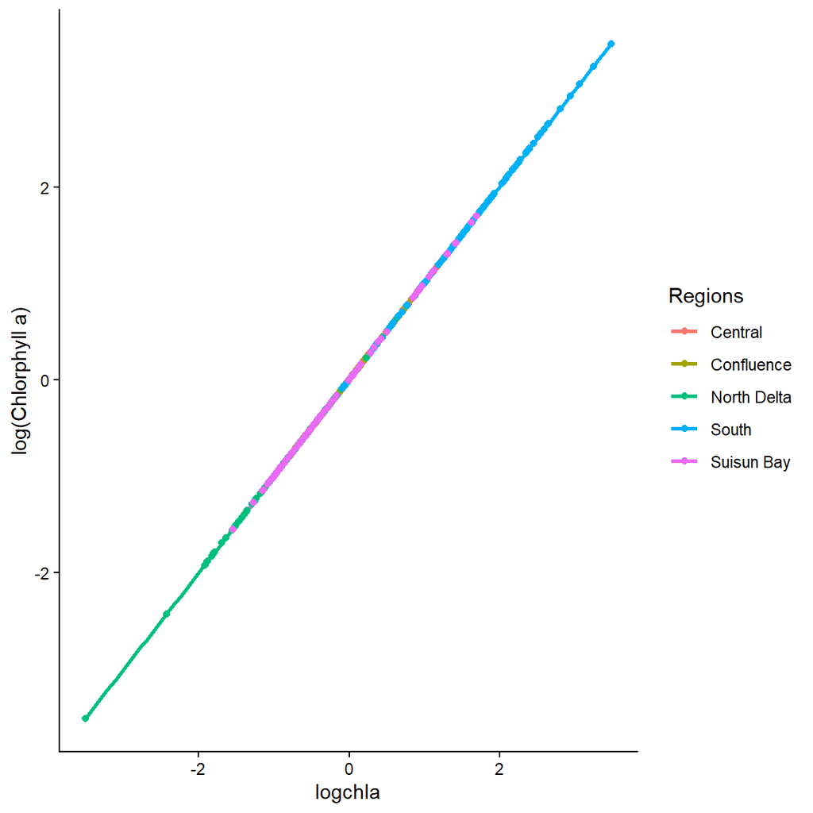

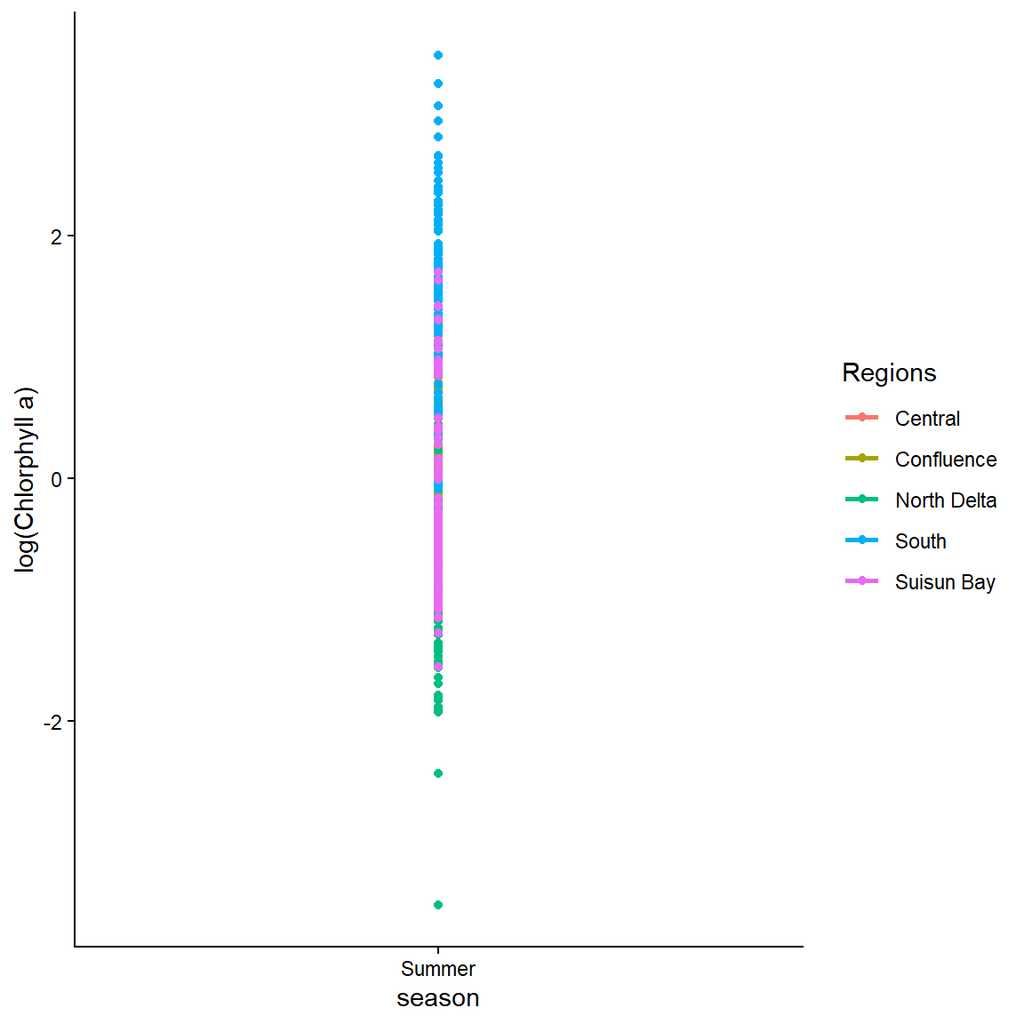

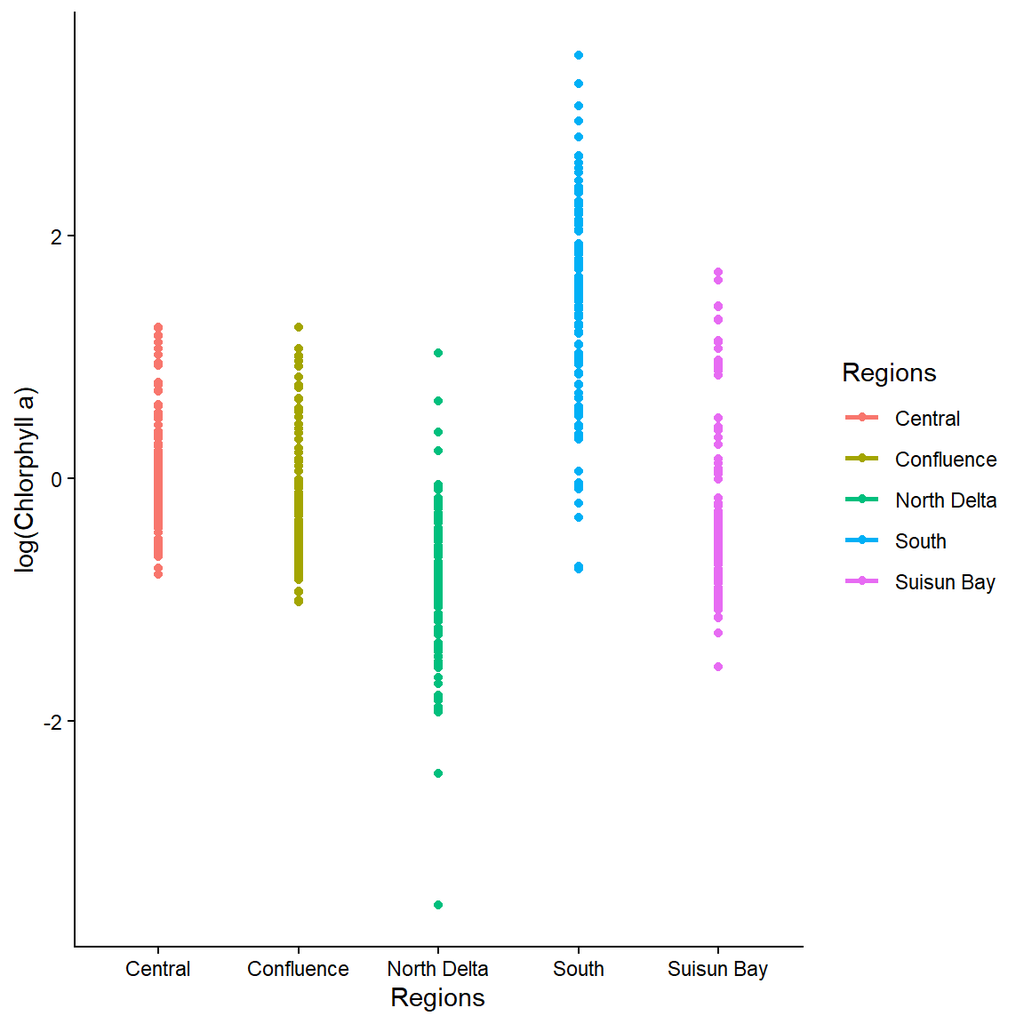

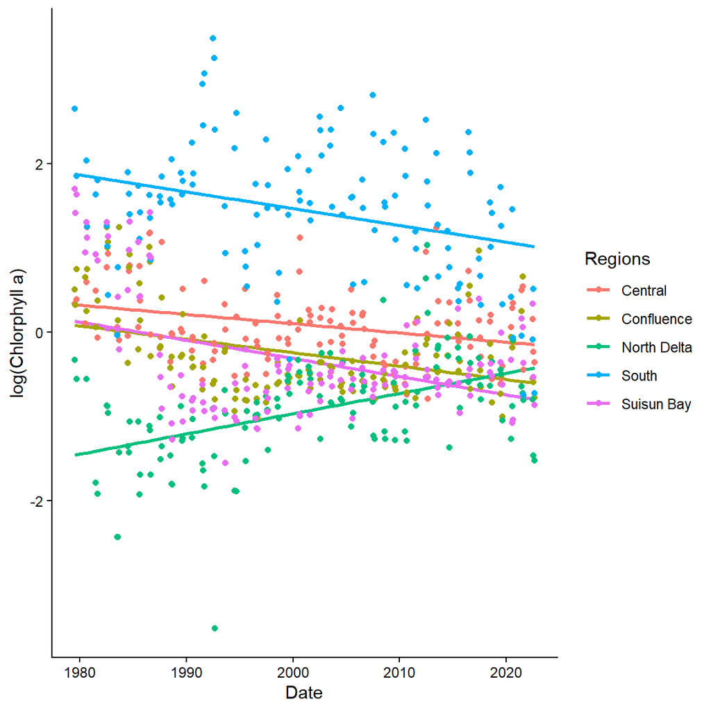

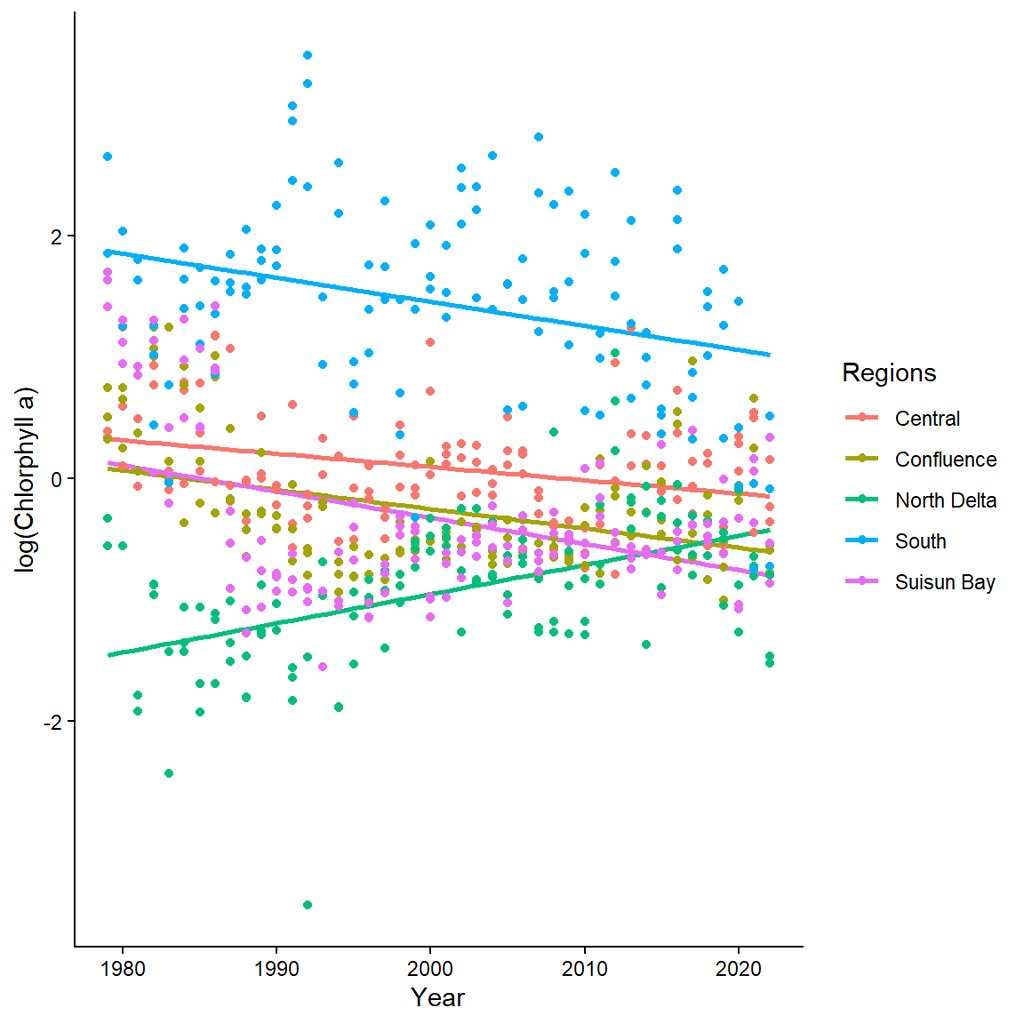

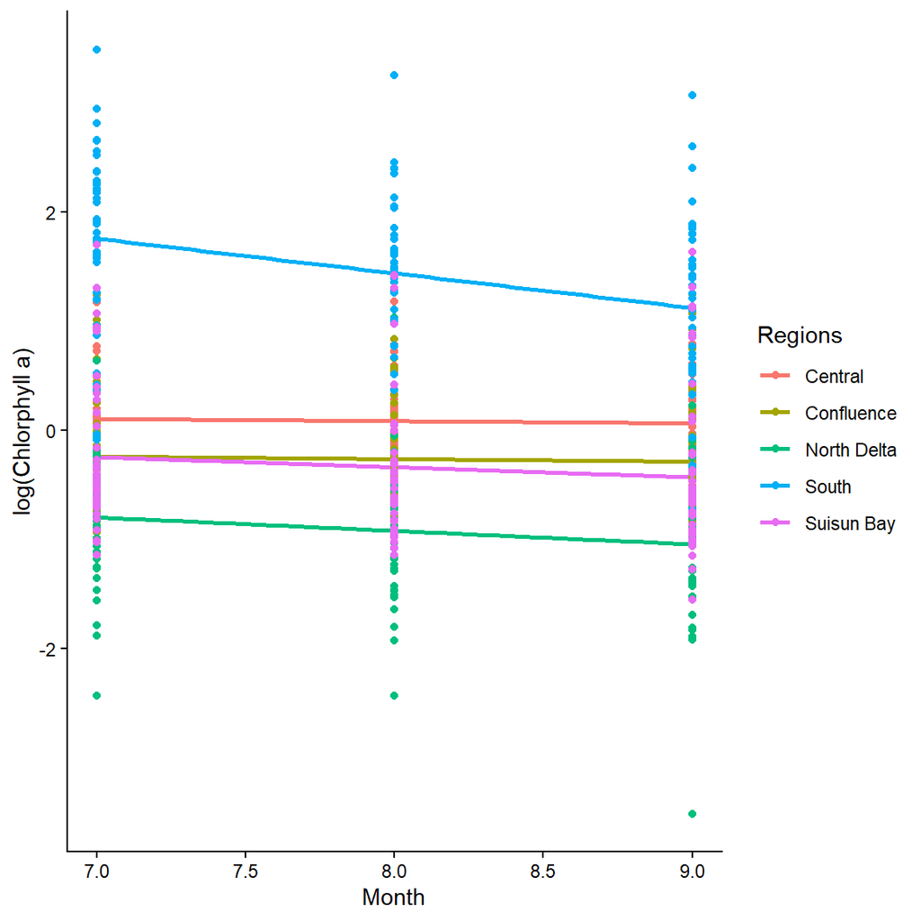

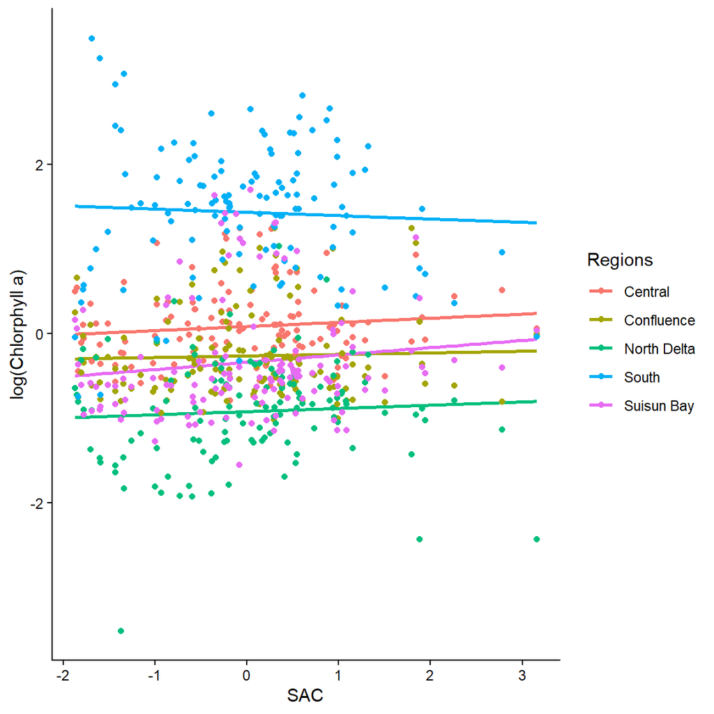

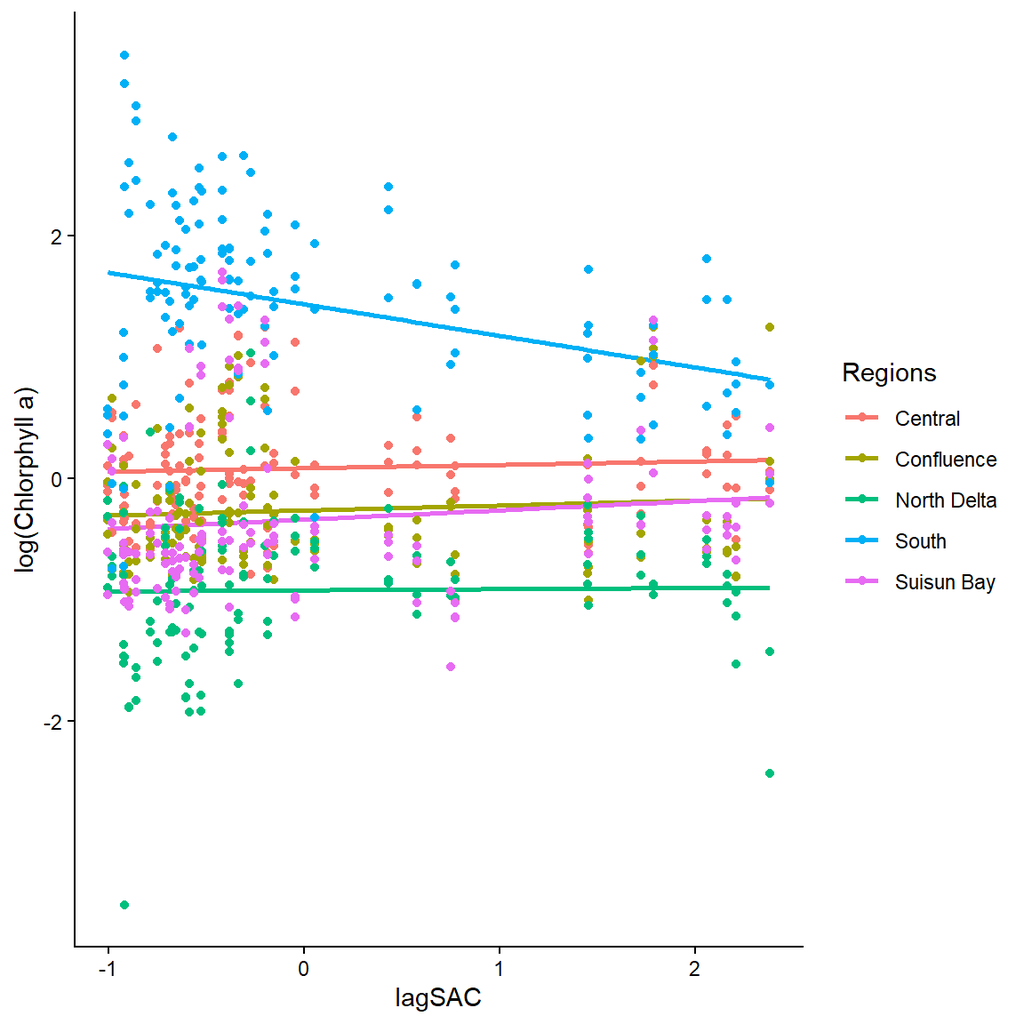

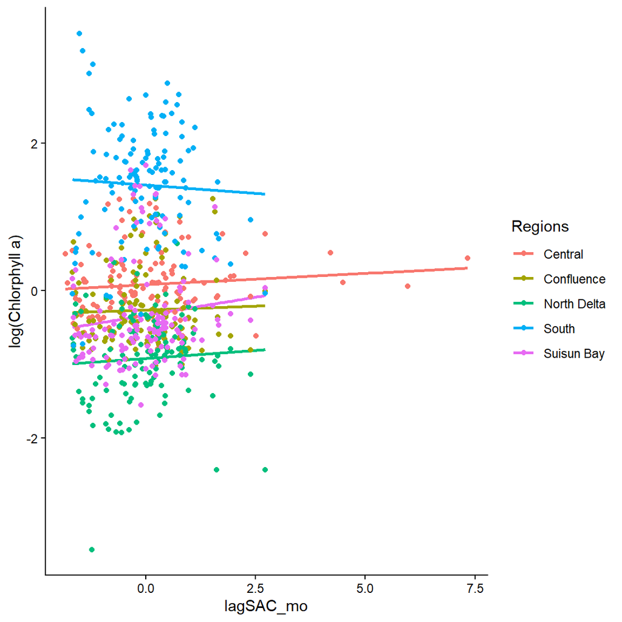

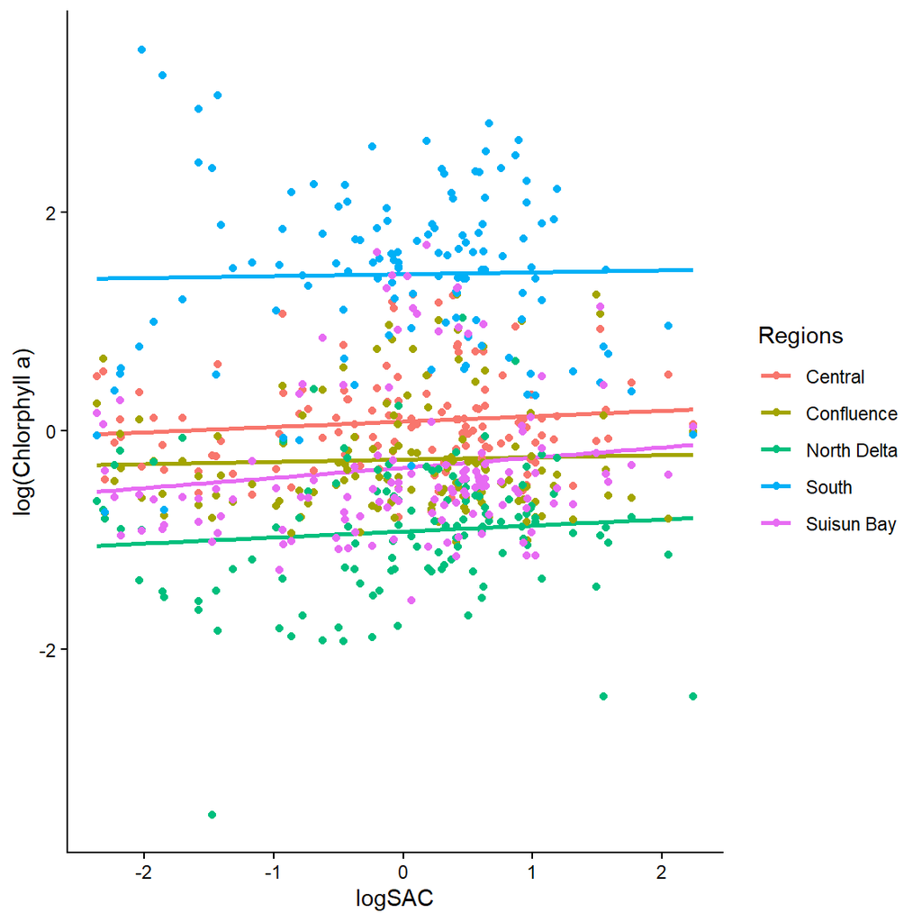

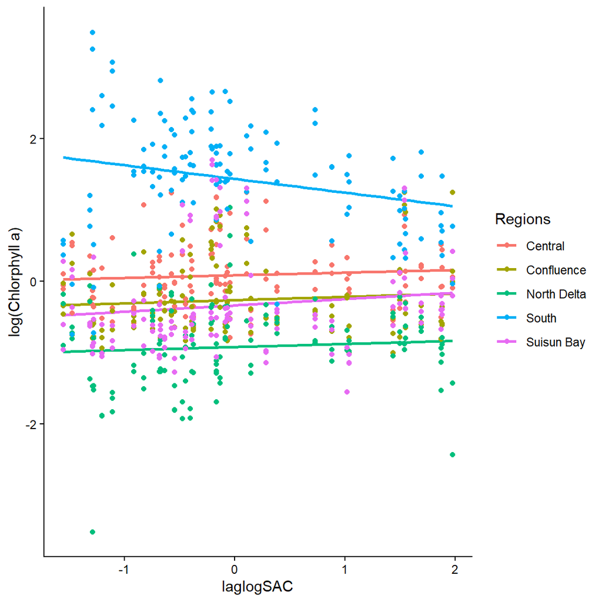

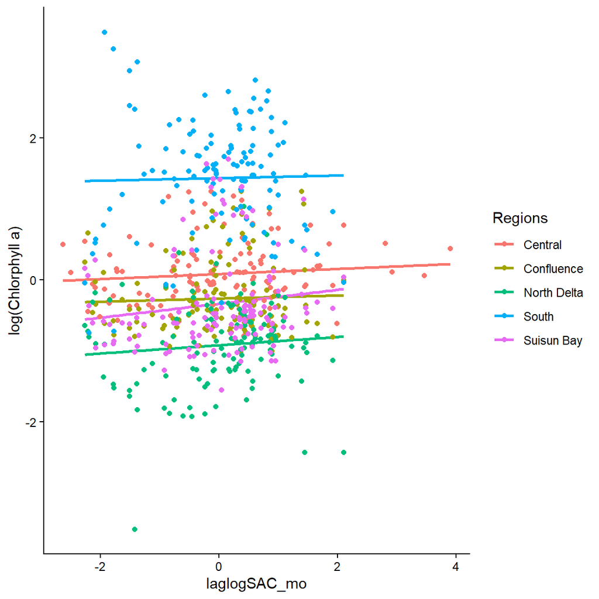

[42 more figures not shown]

```r
lapply(c, function(x) {
  ggplot(smr_z, mapping =aes(x = .data[[x]], y = logchla, color = Regions)) +
    ylab("log(Chlorphyll a)")+
    geom_smooth(method="lm", se=FALSE)+
    geom_point()+
    theme_classic()})
```